# R Notebook

```r
library(tidyverse)
library(modelr)
library(GGally)
library(ggfortify)
```

```r
house_data <- read_csv("data/kc_house_data.csv")
```

# Question 1: Exploratory

```r
summary(house_data)
```

There are no missing values

Columns to be removed: id date sqft_living15 sqft_lot15 zipcode

Columns to be changed: waterfront yr_renovated - to renovated

```r
house_data <- house_data %>%
  mutate(renovated = ifelse(yr_renovated > 0, TRUE, FALSE ))
```

```r
house_data <- house_data %>%
  mutate(waterfront = ifelse(waterfront > 0, TRUE, FALSE ))
```

```r
house_data <- house_data %>%
  mutate(graded = case_when(grade >= 11 ~ 'high quality',
                   grade >= 8 ~ 'above average',
                   grade >= 7 ~ 'average',
                   grade >= 4 ~ 'below average',
                   TRUE ~ 'falls short'
          ))
```

```r
house_data %>%
  group_by(condition) %>%
  summarise(count = n())
```

| condition | count |
| --- | --- |
| 1 | 30 |
| 2 | 172 |
| 3 | 14031 |
| 4 | 5679 |
| 5 | 1701 |

```r
house_data %>%
  group_by(grade) %>%
  summarise(count = n())
```

| grade | count |
| --- | --- |
| 1 | 1 |
| 3 | 3 |
| 4 | 29 |
| 5 | 242 |
| 6 | 2038 |
| 7 | 8981 |
| 8 | 6068 |
| 9 | 2615 |
| 10 | 1134 |
| 11 | 399 |

[output cut: 2 more lines]

```r
# From homework answers
# tidy up data. In particular treat condition and grade as factor, as they are
# ordinal categorical
houses_tidy <- houses %>%
  select(-c("id", "date", "sqft_living15", "sqft_lot15", "zipcode")) %>%
  mutate(waterfront = as.logical(waterfront)) %>%
  mutate(renovated = yr_renovated != 0) %>%
  select(-"yr_renovated") %>%
  mutate(condition = as_factor(condition)) %>%
  mutate(grade = as_factor(grade))

glimpse(houses_tidy)
```

[output not shown]

```r
# Remove extra columns
house_trim <- house_data %>%
  select(-c(renovated, id, date, sqft_living15, sqft_lot15, zipcode))
```

# Question 2

Check for aliased variables using the alias() function (this takes in a formula object and a data set).
$$Hint - formula price \~ . says 'price
varying with all predictors', this is a suitable input to alias()$$
. Remove variables that lead to an alias. Check the ‘Elements of multiple regression’ lesson for a dropdown containing further information on finding aliased variables in a dataset.

```r
alias(lm(price ~ ., data = house_trim))
```

```
Model :
price ~ bedrooms + bathrooms + sqft_living + sqft_lot + floors +
    waterfront + view + condition + grade + sqft_above + sqft_basement +
    yr_built + yr_renovated + lat + long + graded

Complete :
              (Intercept) bedrooms bathrooms sqft_living sqft_lot floors waterfrontTRUE view condition grade sqft_above
sqft_basement  0           0        0         1           0        0      0              0    0         0    -1
              yr_built yr_renovated lat long gradedaverage gradedbelow average gradedfalls short gradedhigh quality
sqft_basement  0        0            0   0    0             0                   0                 0
```

So sqft_basement is the same as sqft_living - sqft_above - so we can remove two of these

```r
# Remove extra columns
house_trim <- house_trim %>%
  select(-c(sqft_living, sqft_basement))
```

```r
# From homework answers
# seems that sqft_basement can be computed from sqft_living - sqft_above.
# let's drop sqft_living leaving just the two contributions sqft_basement and
# sqft_above
houses_tidy <- houses_tidy %>%
  select(-"sqft_living")

glimpse(houses_tidy)
```

[output not shown]

# Question 3

Systematically build a regression model containing up to four main effects (remember, a main effect is just a single predictor with coefficient), testing the regression diagnostics as you go * splitting datasets into numeric and non-numeric columns might help ggpairs() run in manageable time, although you will need to add either a price or resid column to the non-numeric dataframe in order to see its correlations with the non-numeric predictors.

[output not shown]

[output cut: 196 more lines]

[output not shown]

[figure not shown]

```r
house_trim %>%
GGally::ggpairs()
```

Ooooft - that look a bit crazy

[output not shown]

[output cut: 114 more lines]

[output not shown]

[figure not shown]

```r
houses_tidy_numeric <- house_trim %>%
  select_if(is.numeric)

houses_tidy_nonnumeric <- house_trim %>%
  select_if(function(x) !is.numeric(x))

houses_tidy_nonnumeric$price <- house_trim$price

ggpairs(houses_tidy_numeric)
```

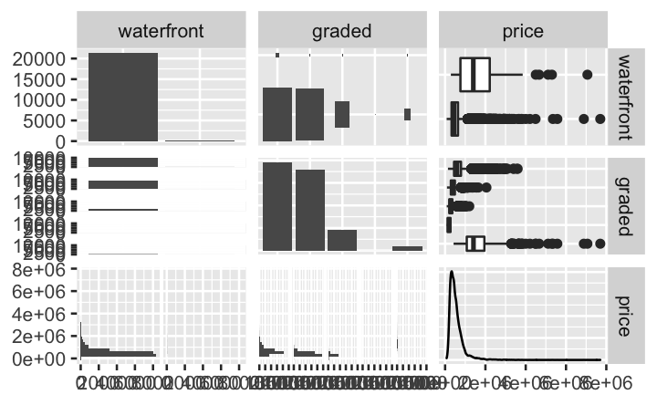

```r
ggpairs(houses_tidy_nonnumeric)
```

```r
cor(houses_tidy_numeric) %>%
  as_data_frame(rownames = "var1") %>%
    pivot_longer(cols = -var1, names_to = "var2", values_to = "coeff") %>%
    filter(var1 != var2) %>%
    filter(var1 == "price") %>%
    arrange(desc(abs(coeff)))
```

| var1 | var2 | coeff |
| --- | --- | --- |
| price | grade | 0.66743426 |
| price | sqft_above | 0.60556730 |
| price | bathrooms | 0.52513751 |
| price | view | 0.39729349 |
| price | bedrooms | 0.30834960 |
| price | lat | 0.30700348 |
| price | floors | 0.25679389 |
| price | yr_renovated | 0.12643379 |
| price | sqft_lot | 0.08966086 |
| price | yr_built | 0.05401153 |

[output cut: 2 more lines]

Looking at all of the different combinations I think the variables I want to consider are: grade sqft_above bathrooms view waterfront

## Building the model - first effect (comparing waterfront and grade)

First I am going to try waterfront (the best fitting non-numeric variable) and grade (the best fitting numeric variable) and see how they compare

```r
mod1a <- lm(price ~ waterfront, data = house_trim)
mod1a
```

```
Call:
lm(formula = price ~ waterfront, data = house_trim)

Coefficients:
   (Intercept)  waterfrontTRUE
        531564         1130312
```

```r
mod1b <- lm(price ~ grade, data = house_trim)
mod1b
```

```
Call:
lm(formula = price ~ grade, data = house_trim)

Coefficients:
(Intercept)        grade
   -1056045       208458
```

Woah - so waterfront has a *huge* effect on price.

For grade the intercept starts much lower at -$1056045 and then goes up $208458

So - let’s start with waterfront

```r
summary(mod1a)
```

```
Call:
lm(formula = price ~ waterfront, data = house_trim)

Residuals:
     Min       1Q   Median       3Q      Max
-1376876  -211564   -81564   108436  7168436

Coefficients:
               Estimate Std. Error t value Pr(>|t|)
(Intercept)      531564       2416  220.00   <2e-16 ***
waterfrontTRUE  1130312      27822   40.63   <2e-16 ***
---
Signif. codes:  0 ‘***’ 0.001 ‘**’ 0.01 ‘*’ 0.05 ‘.’ 0.1 ‘ ’ 1

Residual standard error: 353900 on 21611 degrees of freedom
Multiple R-squared:  0.07095,   Adjusted R-squared:  0.07091
F-statistic:  1650 on 1 and 21611 DF,  p-value: < 2.2e-16
```

Hmm - the R-Squared value is low at only 7% of prices being affected by waterfront So perhaps it is a fantastic indication of price but is only found in a few properties.

Lets have a quick look

```r
house_trim %>%
  group_by(waterfront) %>%
  summarise(count = n())
```

| waterfront | count |
| --- | --- |
| FALSE | 21450 |
| TRUE | 163 |

Only 163 of the properties are waterfront (0.75%) - so it is important for price - but overall has little impact on the rest of the sales

[figure not shown]

```r
par(mfrow = c(2,2))
plot(mod1a)
```

We should definitely keep it in as a model predictor

Now - have a better look at grade:

```r
mod1b <- lm(price ~ grade, data = house_trim)
mod1b
```

```
Call:
lm(formula = price ~ grade, data = house_trim)

Coefficients:
(Intercept)        grade
   -1056045       208458
```

```r
summary(mod1b)
```

```
Call:
lm(formula = price ~ grade, data = house_trim)

Residuals:
    Min      1Q  Median      3Q     Max
-816988 -151958  -36158   97842 6046097

Coefficients:
            Estimate Std. Error t value Pr(>|t|)
(Intercept) -1056045      12256  -86.17   <2e-16 ***
grade         208458       1582  131.76   <2e-16 ***
---
Signif. codes:  0 ‘***’ 0.001 ‘**’ 0.01 ‘*’ 0.05 ‘.’ 0.1 ‘ ’ 1

Residual standard error: 273400 on 21611 degrees of freedom
Multiple R-squared:  0.4455,    Adjusted R-squared:  0.4454
F-statistic: 1.736e+04 on 1 and 21611 DF,  p-value: < 2.2e-16
```

The Rsquared value is much higher: 44.55% of the prices are affected by grade and with a very small p-value this is also significant

[figure not shown]

```r
par(mfrow = c(2,2))
plot(mod1b)
```

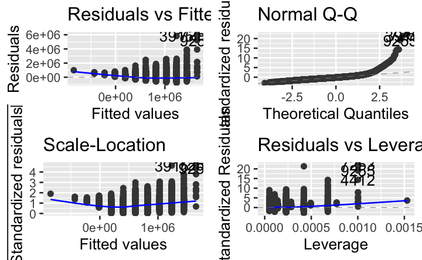

```r
autoplot(mod1b)
```

## Adding in the second variable

```r
mod1a <- lm(price ~ waterfront, data = house_trim)
mod1a
```

```
Call:
lm(formula = price ~ waterfront, data = house_trim)

Coefficients:
   (Intercept)  waterfrontTRUE
        531564         1130312
```

```r
house_remaining_resid <- house_trim %>%
  add_residuals(mod1a) %>%
  select(-c("price", "waterfront"))
house_remaining_resid
```

| bedrooms | bathrooms | sqft_lot | floors | view | condition | grade | sqft_above | yr_built | yr_renovated | lat | long | graded | resid |
| --- | --- | --- | --- | --- | --- | --- | --- | --- | --- | --- | --- | --- | --- |
| 3 | 1.00 | 5650 | 1.0 | 0 | 3 | 7 | 1180 | 1955 | 0 | 47.5112 | -122.257 | average | -309663.5998 |
| 3 | 2.25 | 7242 | 2.0 | 0 | 3 | 7 | 2170 | 1951 | 1991 | 47.7210 | -122.319 | average | 6436.4002 |
| 2 | 1.00 | 10000 | 1.0 | 0 | 3 | 6 | 770 | 1933 | 0 | 47.7379 | -122.233 | below average | -351563.5998 |
| 4 | 3.00 | 5000 | 1.0 | 0 | 5 | 7 | 1050 | 1965 | 0 | 47.5208 | -122.393 | average | 72436.4002 |
| 3 | 2.00 | 8080 | 1.0 | 0 | 3 | 8 | 1680 | 1987 | 0 | 47.6168 | -122.045 | above average | -21563.5998 |
| 4 | 4.50 | 101930 | 1.0 | 0 | 3 | 11 | 3890 | 2001 | 0 | 47.6561 | -122.005 | high quality | 693436.4002 |
| 3 | 2.25 | 6819 | 2.0 | 0 | 3 | 7 | 1715 | 1995 | 0 | 47.3097 | -122.327 | average | -274063.5998 |
| 3 | 1.50 | 9711 | 1.0 | 0 | 3 | 7 | 1060 | 1963 | 0 | 47.4095 | -122.315 | average | -239713.5998 |
| 3 | 1.00 | 7470 | 1.0 | 0 | 3 | 7 | 1050 | 1960 | 0 | 47.5123 | -122.337 | average | -302063.5998 |
| 3 | 2.50 | 6560 | 2.0 | 0 | 3 | 7 | 1890 | 2003 | 0 | 47.3684 | -122.031 | average | -208563.5998 |

[output cut: 990 more lines]

[output not shown]

[output cut: 154 more lines]

[output not shown]

[figure not shown]

```r
house_remaining_resid %>%
GGally::ggpairs()
```

```r
mod1d <- lm(resid ~ grade, data = house_remaining_resid)
mod1d
```

```
Call:
lm(formula = resid ~ grade, data = house_remaining_resid)

Coefficients:
(Intercept)        grade
   -1543405       201571
```

Resid is our predicted value

Resid = -1543405 + (201571 x grade)

```r
#Re -running with correct column
mod1da <- lm(resid ~ graded, data = house_remaining_resid)
mod1da
```

```
Call:
lm(formula = resid ~ graded, data = house_remaining_resid)

Coefficients:
        (Intercept)        gradedaverage  gradedbelow average    gradedfalls short   gradedhigh quality
             123121              -254989              -367293              -464934               954151
```

```r
# Comparing two versions of grade/graded
summary(mod1d)
```

```
Call:
lm(formula = resid ~ grade, data = house_remaining_resid)

Residuals:
     Min       1Q   Median       3Q      Max
-1754183  -145870   -30728   100843  6091416

Coefficients:
            Estimate Std. Error t value Pr(>|t|)
(Intercept) -1543405      11782  -131.0   <2e-16 ***
grade         201571       1521   132.5   <2e-16 ***
---
Signif. codes:  0 ‘***’ 0.001 ‘**’ 0.01 ‘*’ 0.05 ‘.’ 0.1 ‘ ’ 1

Residual standard error: 262800 on 21611 degrees of freedom
Multiple R-squared:  0.4483,    Adjusted R-squared:  0.4483
F-statistic: 1.756e+04 on 1 and 21611 DF,  p-value: < 2.2e-16
```

```r
summary(mod1da)
```

```
Call:
lm(formula = resid ~ graded, data = house_remaining_resid)

Residuals:
     Min       1Q   Median       3Q      Max
-1404997  -144684   -39684    99304  6091165

Coefficients:
                    Estimate Std. Error t value Pr(>|t|)
(Intercept)           123121       2815  43.742  < 2e-16 ***
gradedaverage        -254989       4072 -62.618  < 2e-16 ***
gradedbelow average  -367293       6450 -56.943  < 2e-16 ***
gradedfalls short    -464934     139468  -3.334 0.000859 ***
gradedhigh quality    954150      12761  74.769  < 2e-16 ***
---
Signif. codes:  0 ‘***’ 0.001 ‘**’ 0.01 ‘*’ 0.05 ‘.’ 0.1 ‘ ’ 1

Residual standard error: 278900 on 21608 degrees of freedom
Multiple R-squared:  0.379, Adjusted R-squared:  0.3789
F-statistic:  3297 on 4 and 21608 DF,  p-value: < 2.2e-16
```

44.8% of property prices are affected by waterfront and grade 37.9% if it is split into categories - so keeping it as individual numbers is more efficient

[figure not shown]

```r
par(mfrow = c(2,2))
plot(mod1d)
```

## Adding the next one in

```r
mod2b <- lm(price ~ waterfront + grade + sqft_above, data = house_trim)
summary(mod2b)
```

```
Call:
lm(formula = price ~ waterfront + grade + sqft_above, data = house_trim)

Residuals:
     Min       1Q   Median       3Q      Max
-1372544  -144364   -30604   100831  5678622

Coefficients:
                 Estimate Std. Error t value Pr(>|t|)
(Intercept)    -7.866e+05  1.366e+04  -57.60   <2e-16 ***
waterfrontTRUE  8.927e+05  2.021e+04   44.17   <2e-16 ***
grade           1.485e+05  2.266e+03   65.50   <2e-16 ***
sqft_above      1.025e+02  3.214e+00   31.87   <2e-16 ***
---
Signif. codes:  0 ‘***’ 0.001 ‘**’ 0.01 ‘*’ 0.05 ‘.’ 0.1 ‘ ’ 1

Residual standard error: 256200 on 21609 degrees of freedom
Multiple R-squared:  0.5132,    Adjusted R-squared:  0.5132
F-statistic:  7595 on 3 and 21609 DF,  p-value: < 2.2e-16
```

51% can now be predicted with waterfront, grade and sqft

```r
anova(mod2b, mod1d)
```

```
Analysis of Variance Table

Response: price
              Df     Sum Sq    Mean Sq F value    Pr(>F)
waterfront     1 2.0668e+14 2.0668e+14  3149.8 < 2.2e-16 ***
grade          1 1.2217e+15 1.2217e+15 18618.1 < 2.2e-16 ***
sqft_above     1 6.6653e+13 6.6653e+13  1015.8 < 2.2e-16 ***
Residuals  21609 1.4179e+15 6.5617e+10
---
Signif. codes:  0 ‘***’ 0.001 ‘**’ 0.01 ‘*’ 0.05 ‘.’ 0.1 ‘ ’ 1
```

## Adding the last one

```r
mod2c <- lm(price ~ waterfront + grade + sqft_above + bathrooms, data = house_trim)
summary(mod2c)
```

```
Call:
lm(formula = price ~ waterfront + grade + sqft_above + bathrooms,
    data = house_trim)

Residuals:
     Min       1Q   Median       3Q      Max
-1368867  -145207   -30361   103237  5604635

Coefficients:
                 Estimate Std. Error t value Pr(>|t|)
(Intercept)    -7.750e+05  1.365e+04  -56.77   <2e-16 ***
waterfrontTRUE  8.911e+05  2.015e+04   44.22   <2e-16 ***
grade           1.402e+05  2.375e+03   59.01   <2e-16 ***
sqft_above      8.778e+01  3.455e+00   25.41   <2e-16 ***
bathrooms       3.701e+04  3.256e+03   11.37   <2e-16 ***
---
Signif. codes:  0 ‘***’ 0.001 ‘**’ 0.01 ‘*’ 0.05 ‘.’ 0.1 ‘ ’ 1

Residual standard error: 255400 on 21608 degrees of freedom
Multiple R-squared:  0.5161,    Adjusted R-squared:  0.516
F-statistic:  5762 on 4 and 21608 DF,  p-value: < 2.2e-16
```

```r
anova(mod2c, mod2b)
```

```
Analysis of Variance Table

Model 1: price ~ waterfront + grade + sqft_above + bathrooms
Model 2: price ~ waterfront + grade + sqft_above
  Res.Df        RSS Df   Sum of Sq     F    Pr(>F)
1  21608 1.4095e+15
2  21609 1.4179e+15 -1 -8.4279e+12 129.2 < 2.2e-16 ***
---
Signif. codes:  0 ‘***’ 0.001 ‘**’ 0.01 ‘*’ 0.05 ‘.’ 0.1 ‘ ’ 1
```

Final linear model:

```r
lm(formula = price ~ waterfront + grade + sqft_above + bathrooms,
    data = house_trim)
```

```
Call:
lm(formula = price ~ waterfront + grade + sqft_above + bathrooms,
    data = house_trim)

Coefficients:
   (Intercept)  waterfrontTRUE           grade      sqft_above       bathrooms
    -775042.84       891132.87       140155.02           87.78        37012.24
```

51.6%